# MHHS Scoring

```r
library(psych)
library(tidyverse)
library(apaTables)
library(tableone)
library(dplyr)
```

```r
# Note that there's a package that does this smoothly. Need to add it as an alternative at some point

#columnNames<-read.csv("../01-RawData/MHHS-1_12202023.csv",header=FALSE)[1,]

#qual_data<-read.csv("../01-RawData/MHHS-1_12202023.csv",header=FALSE,col.names = columnNames)[-c(1:3),]

# write a new version that can be reimported with the proper column classes
#write.csv(qual_data,"../04-ProcessedData/MHHS-1_12202023_cleanheader.csv",row.names=FALSE)
```

```r
mhhs_data<-read.csv("../04-ProcessedData/MHHS-1_12202023_cleanheader.csv")
```

```r
CreateTableOne(data=mhhs_demotbl)
```

```
                                 Overall
  n                               887
  Race_Ethn2 (%)
     Not answered                  23 ( 2.6)
     White                        319 (36.0)
     Black                        120 (13.5)
     Hispanic                     136 (15.3)
     Asian                        218 (24.6)
     AmerIndian                     2 ( 0.2)
     PacificIslander                3 ( 0.3)
     Multiracial                   66 ( 7.4)
  BIC_1 (%)
     Not answered                  17 ( 1.9)
     NotBicultural                444 (50.1)
     Bicultural                   426 (48.0)
  LANG_1 (%)
     Not Answered                  16 ( 1.8)
     English at Home              442 (49.8)
     Additional Language at Home  429 (48.4)
  EDUC_Par (%)
     Not answered                  23 ( 2.6)
     <High School                  40 ( 4.5)
     High School                  109 (12.3)
     Some college                 108 (12.2)
     Associates                    45 ( 5.1)
     Bachelors                    275 (31.0)
     Masters                      220 (24.8)
     Doctoral/Professional         67 ( 7.6)
  EDUC_Self (%)
     Not answered                  25 ( 2.8)
     <High School                 278 (31.4)
     High School                   59 ( 6.7)
     Some college                 180 (20.3)
     Associates                   131 (14.8)
     Bachelors                    132 (14.9)
     Masters                       74 ( 8.4)
     Doctoral/Professional          6 ( 0.7)
  GENDER (%)
     Not answered                  23 ( 2.6)
     cis-woman                    565 (63.7)
```

[output cut: 20 more lines]

```
     Active Duty                    4 ( 0.5)
     National Guard                 3 ( 0.3)
     Military Spouse                2 ( 0.2)
     Military Dependent            34 ( 3.8)
     Veteran                        6 ( 0.7)
     Other                          5 ( 0.6)
     Prefer not to respond          2 ( 0.2)
  Income (%)
     Not answered                 173 (19.5)
     Less than 10k                 50 ( 5.6)
     10,000-20,000                 42 ( 4.7)
     20,000-50,000                132 (14.9)
     50,000-100,000               225 (25.4)
     100,000-150,000              154 (17.4)
     150,000+                     111 (12.5)
```

# PROMIS_Global v1.2

To score the PROMIS_Global: First check if survey coded Excellent as 1 or as 5. Qualtrics will often reverse them. Higher scores should reflect better functioning.

PROMIS_Global1_1:PROMIS_Global1_7: Items rated from 5 (excellent) to 1 (Not at all) on original scale; PROMIS_Global1_1:PROMIS_Global1_7 are reversed from Qualtrics 1-5 defaults

PROMIS_Global2_1: emotional problems; past 7 days; 5 (never) to 1 (always); (global 10) PROMIS_Global2_2: fatigue; past 7 days (global 08)

PROMIS_Global3_1: pain. 5=0, 4=1:3, 3=4:6, 2=7:9, 1=10

For scoring, “2 questions were excluded from the calculation/evaluation as a result of the questionnaire development study: Global01 because of its statistical congruence with Global03. Global09r because of its approximately equal statistical correlation to physical and mental health.”

The Global Physical Health score is generated by summing responses to Global03 (PROMIS_Global1_3), Global06 (PROMIS_Global1_7), Global07rescored (PROMIS_Global3_1), and Global08rescored (PROMIS_Global2_2). The Global Mental Health score is generated by summing responses to Global02 (PROMIS_Global1_2), Global04 (PROMIS_Global1_4), Global05(PROMIS_Global1_5), and Global10rescored (PROMIS_Global2_1)

```r
promis_global<-mhhs_data %>% select(contains("PROMIS"))

#score items so that higher scores reflect better functioning

# pain item: 5=0, 4=1:3, 3=4:6, 2=7:9, 1=10

# renaming the Promis to match the original measure

promis_global<-promis_global %>% rename_with(~sprintf("PROMIS_Global0%d",1:5),.cols=c(PROMIS_Global1_1:PROMIS_Global1_5)) %>%  rename(PROMIS_Global09=PROMIS_Global1_6,PROMIS_Global06=PROMIS_Global1_7, PROMIS_Global10=PROMIS_Global2_1, PROMIS_Global08=PROMIS_Global2_2,PROMIS_Global07=PROMIS_Global3_1)%>% mutate(across(c(PROMIS_Global01:PROMIS_Global08),~6-.)) %>%
  mutate(PROMIS_Global07=recode(PROMIS_Global07,`0`=5,`1`=4,`2`=4,`3`=4,`4`=3,`5`=3,`6`=3,`7`=2,`8`=2,`9`=2,`10`=1))%>%
  rowwise() %>%  mutate(PG_PhysHealth=sum(c(PROMIS_Global03,PROMIS_Global06,PROMIS_Global07,PROMIS_Global08)),PG_MentHealth=sum(c(PROMIS_Global02,PROMIS_Global04,PROMIS_Global05,PROMIS_Global10))) %>% ungroup()

promis_global_scoring<-promis_global %>% select(-PROMIS_Global01, -PROMIS_Global09,-PG_PhysHealth,-PG_MentHealth)

key_promis.list<-list(PH=c("PROMIS_Global03","PROMIS_Global06","PROMIS_Global07","PROMIS_Global08"),MH=c("PROMIS_Global02","PROMIS_Global04","PROMIS_Global05","PROMIS_Global10"))

key_promis<-make.keys(nvars=8,key_promis.list,item.labels = colnames(promis_global_scoring))
scales_promis<-scoreItems(key_promis,promis_global_scoring)
summary(scales_promis)
```

[output not shown]

# GHSQL

GHSQL has one open-response item. This is not included in the summary score. Scoring also seems somewhat flexible and includes informal/formal; personal-emotional/suicide; help from anyone/Help from no-one.

Range 1-7 (Extremely unlikely to Extremely Likely)

```r
ghsql<-mhhs_data %>% select(contains("GHSQL"))

ghsql<-ghsql %>% mutate(General=rowSums((select(ghsql,GHSQL_Pers_1:GHSQL_Pers_9,GHSQL_SUI_1:GHSQL_SUI_9)))) %>%
 rowwise() %>%
  mutate(Personal=sum(c_across(GHSQL_Pers_1:GHSQL_Pers_8)),
         Suicide=sum(c_across(GHSQL_SUI_1:GHSQL_SUI_8)),
         Informal_all=sum(c(GHSQL_Pers_1,GHSQL_SUI_1,GHSQL_Pers_2,GHSQL_SUI_2,GHSQL_Pers_3,GHSQL_SUI_3,GHSQL_Pers_4,GHSQL_SUI_4)),
         Formal_all=sum(c(GHSQL_Pers_5,GHSQL_SUI_5,GHSQL_Pers_6,GHSQL_SUI_6,GHSQL_Pers_7,GHSQL_SUI_7,GHSQL_Pers_8,GHSQL_SUI_8)),
         None_all=sum(c(GHSQL_Pers_9,GHSQL_SUI_9))) %>%
  ungroup() %>% #remove rowwise grouping
  mutate(Personal_z=scale(Personal),Suicide_z=scale(Suicide),Informal_all_z=scale(Informal_all),Formal_all_z=scale(Formal_all),None_all_z=scale(None_all))

#make a dataframe with only the items to be scored/that need reliability
ghsql_scoring<-ghsql %>% dplyr::select(1:9,12:20)
key_ghsql.list<-list(General=c(1:18),Personal=c(1:9),Suicide=c(10:18),Formal=c(5,14,6,15,7,16,8,17),Informal=c(1,10,2,11,3,12,4,13))
key_ghsql<-make.keys(18,key_ghsql.list,colnames(ghsql_scoring))

scales_ghsql<-scoreItems(key_ghsql.list,ghsql_scoring)
summary(scales_ghsql)
```

```
Call: scoreItems(keys = key_ghsql.list, items = ghsql_scoring)

Scale intercorrelations corrected for attenuation
 raw correlations below the diagonal, (unstandardized) alpha on the diagonal
 corrected correlations above the diagonal:
         General Personal Suicide Formal Informal
General     0.78     1.36    1.24   1.07     1.05
Personal    0.87     0.52    1.03   1.16     1.06
Suicide     0.93     0.63    0.72   1.03     1.05
Formal      0.86     0.76    0.80   0.83     0.59
Informal    0.82     0.68    0.79   0.48     0.78
```

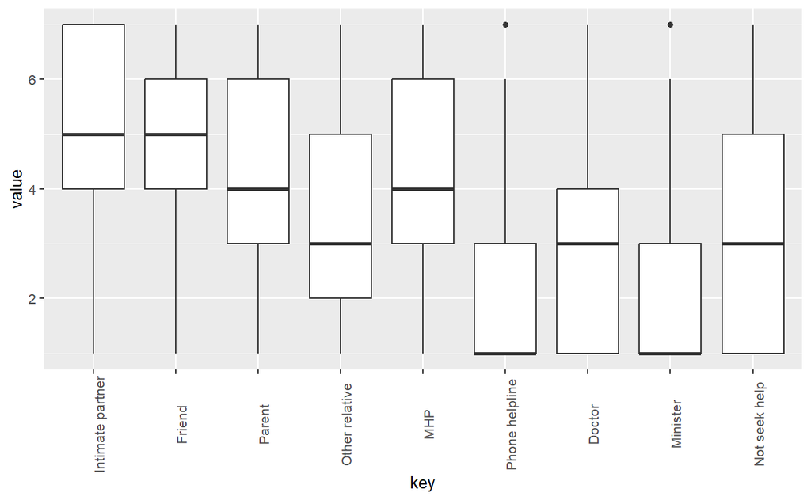

```r
#histogram to explore the range
ghsql %>% select(GHSQL_Pers_1:GHSQL_Pers_9) %>% gather() %>% ggplot(aes(y=value,x=key)) + geom_boxplot() + scale_x_discrete(labels=c("Intimate partner", "Friend","Parent","Other relative","MHP","Phone helpline","Doctor","Minister","Not seek help"))+ theme(axis.text.x = element_text(angle=90))
```

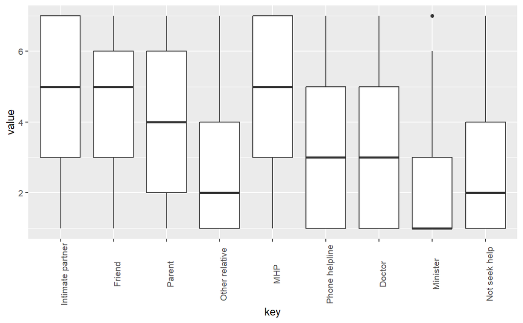

```r
ghsql %>% select(GHSQL_SUI_1:GHSQL_SUI_9) %>% gather() %>% ggplot(aes(y=value,x=key)) + geom_boxplot() + scale_x_discrete(labels=c("Intimate partner", "Friend","Parent","Other relative","MHP","Phone helpline","Doctor","Minister","Not seek help"))+ theme(axis.text.x = element_text(angle=90))
```

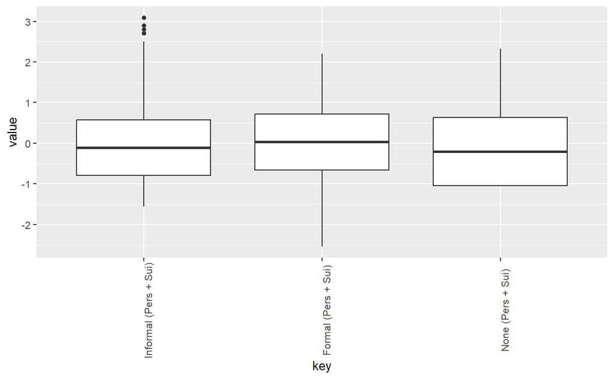

```r
ghsql %>% select(Informal_all_z,Formal_all_z,None_all_z) %>% gather() %>% ggplot(aes(y=value,x=key)) + geom_boxplot() + scale_x_discrete(labels=c("Informal (Pers + Sui)","Formal (Pers + Sui)","None (Pers + Sui)"))+ theme(axis.text.x = element_text(angle=90))
```

```r
ghsql %>% select(GHSQL_Pers_10_TEXT,GHSQL_SUI_10_TEXT) %>% filter(GHSQL_Pers_10_TEXT!=""|GHSQL_SUI_10_TEXT!="")
```

| GHSQL_Pers_10_TEXT | GHSQL_SUI_10_TEXT |
| --- | --- |
| former teacher | former teacher |
| My best friend |  |
| If feel like it depends on what the issue is. If it would be a problem related to work, than a trusted co-worker may be a good person to talk to, or sharing an issue in class may be best to share with… |  |
| Sister | Sister |
| sister |  |
| coworker/manager |  |
| online friends |  |
| online sources |  |
| Placerat gravida! Non? At urna velit mattis. Nec etiam viverra. | Id velit odio aenean eget placerat ultricies. Phasellus eu integer. |
| Sapien sagittis etiam vestibulum sollicitudin fringilla donec posuere vulputate maecenas natoque luctus. | Pharetra dignissim, suscipit tortor, elementum natoque mattis curabitur dignissim? Justo urna. Vulputate rutrum. |

[output cut: 35 more lines]

```r
NA
```

# DASS21

Stress items are 1, 6, 8, 11, 12, 14, 18 Anxiety items are 2, 4, 7, 9, 15, 19, 20,  
Depression items are 3, 5, 10, 13, 16, 17, 21

The depression scale assesses dysphoria, hopelessness, devaluation of life, self-deprecation, lack of interest / involvement, anhedonia and inertia.

The anxiety scale assesses autonomic arousal, skeletal muscle effects, situational anxiety, and subjective experience of anxious affect. The stress scale is sensitive to levels of chronic nonspecific arousal. It assesses difficulty relaxing, nervous arousal, and being easily upset / agitated, irritable / over-reactive and impatient.

Scores for depression, anxiety and stress are calculated by summing the scores for the relevant items

Scores on the DASS-21 will need to be multiplied by 2 to calculate the final score and stay equivalent with DASS-42.

```r
dass<-mhhs_data %>% select(contains("DASS"))

dass<-dass %>% mutate(Dass21_Total=rowSums((select(dass,DASS21_1:DASS21_21)))*2) %>%
 rowwise() %>%
  mutate(Dass21_Stress=sum(DASS21_1,DASS21_6, DASS21_8,DASS21_11,DASS21_12,DASS21_14,DASS21_18,na.rm = T),
         Dass21_Anxiety=sum(DASS21_2,DASS21_4,DASS21_7,DASS21_9,DASS21_15,DASS21_19,DASS21_20, na.rm=T),
         Dass21_Depression=sum(DASS21_3,DASS21_5,DASS21_10,DASS21_13,DASS21_16,DASS21_17,DASS21_21, na.rm=T)) %>%
  ungroup() %>%
  mutate(Dass21_Stress_z=scale(.,)) %>%
  mutate(Dep_cuts=case_when(Dass21_Depression<10~"Normal",
                                   Dass21_Depression<14~"Mild",
                                   Dass21_Depression<21~"Moderate",
                                   Dass21_Depression<28~"Severe",
                                   Dass21_Depression>27~"Extremely_Severe"),
                Anx_cuts=case_when(Dass21_Anxiety<8~"Normal",
                                   Dass21_Anxiety<10~"Mild",
                                   Dass21_Anxiety<15~"Moderate",
                                   Dass21_Anxiety<20~"Severe",
                                   Dass21_Anxiety>19~"Extremely_Severe"),
                Stress_cuts=case_when(Dass21_Stress<15~"Normal",
                                   Dass21_Stress<19~"Mild",
                                   Dass21_Stress<26~"Moderate",
                                   Dass21_Stress<34~"Severe",
                                   Dass21_Stress>33~"Extremely_Severe"))


#make a dataframe with only the items to be scored/that need reliability
dass_scoring<-dass %>% dplyr::select(DASS21_1:DASS21_21)
key_dass.list<-list(Stress=c(1,6,8,11,12,14,18),Anxiety=c(2,4,7,9,15,19,20),Depression=c(3,5,10,13,16,17,21))

key_dass<-make.keys(21,key_dass.list,colnames(dass_scoring))

scales_dass<-scoreItems(key_dass.list,dass_scoring)
summary(scales_dass)

#histogram to explore the range
dass %>% select(Dass21_Stress,Dass21_Anxiety, Dass21_Depression) %>% gather() %>% ggplot(aes(y=value,x=key)) + geom_boxplot() + scale_x_discrete(labels=c("Stress","Anxiety","Depression"))+ theme(axis.text.x = element_text(angle=90))

#scatterplot to color the cutoffs
dass_severity<-dass %>%  select(Dass21_Stress,Dass21_Anxiety, Dass21_Depression) %>%
pivot_longer(cols=starts_with("Dass21"),names_to = "Subscale",values_to = "score") %>%   mutate(Cuts=case_when((Subscale=="Dass21_Depression" & score<10) ~"Normal",
                       (Subscale== "Dass21_Depression"& score<14)~"Mild",
                       (Subscale== "Dass21_Depression"& score<21)~"Moderate",
                       (Subscale== "Dass21_Depression"& score<28)~"Severe",
                       (Subscale== "Dass21_Depression"& score>27)~"Extremely_Severe",
                       (Subscale=="Dass21_Anxiety"& score<8)~"Normal",
                      (Subscale== "Dass21_Anxiety"& score<10)~"Mild",
                      (Subscale== "Dass21_Anxiety"& score<15)~"Moderate",
                      (Subscale== "Dass21_Anxiety"& score<20)~"Severe",
                      (Subscale== "Dass21_Anxiety"& score>19)~"Extremely_Severe",
                      (Subscale=="Dass21_Stress"& score<15)~"Normal",
                      (Subscale=="Dass21_Stress"& score<19)~"Mild",
                      (Subscale=="Dass21_Stress"& score<26)~"Moderate",
                      (Subscale== "Dass21_Stress"& score<34)~"Severe",
                      (Subscale== "Dass21_Stress"& score>33)~"Extremely_Severe"))


#severity histogram colored by severity
dass_scatter %>% ggplot(aes(score,fill=Subscale,group=Subscale))+geom_bar()

#jitter plot colored by severity
dass_scatter %>% ggplot(aes(x=Subscale,y=score,colour=Cuts))+geom_jitter()+theme_classic()+scale_color_brewer(palette = "Set1")
```

[output not shown]

# ISMI29

29-item measure assessing self stigma of mental illness. Includes subscales: alienation, stereotype endorsement, discrimination experience, social withdrawal, stigma resistance. Scored from 1-4. The entire Stigma resistance subscale is reverse scored.

Traditional scoring is dichotomous and uses means.

```r
ismi<-mhhs_data %>% select(contains("ISMI"))

ismi<-ismi %>% rowwise() %>%
  mutate(ISMI_Alientation=sum(ISMI29_1,ISMI29_5,ISMI29_8,ISMI29_16,ISMI29_17,ISMI29_21),
         ISMI_Stere=sum(ISMI29_2, ISMI29_6,ISMI29_10,ISMI29_18,ISMI29_19,ISMI29_23,ISMI29_29),
         ISMI_Discr=sum(ISMI29_3,ISMI29_15,ISMI29_22,ISMI29_25,ISMI29_28),
    ISMI_Withdrawal=sum(ISMI29_4,ISMI29_9,ISMI29_11,ISMI29_12,ISMI29_13,ISMI29_20)) %>%
      mutate(ISMI29_7=recode(ISMI29_7,`1`=4,`2`=3,`3`=2,`4`=1),
            ISMI29_14=recode(ISMI29_14,`1`=4,`2`=3,`3`=2,`4`=1),
         ISMI29_24=recode(ISMI29_24,`1`=4,`2`=3,`3`=2,`4`=1),
          ISMI29_26=recode(ISMI29_26,`1`=4,`2`=3,`3`=2,`4`=1),
         ISMI29_27=recode(ISMI29_27,`1`=4,`2`=3,`3`=2,`4`=1)) %>%
      mutate(ISMI_Stigmar=sum(ISMI29_7,ISMI29_14,ISMI29_24,ISMI29_26,ISMI29_27)) %>%
  ungroup()


#make a dataframe with only the items to be scored/that need reliability
ismi_scoring<-ismi %>% dplyr::select(ISMI29_1:ISMI29_29)
key_ismi.list<-list(Alien=c(1,5,8,16,17,21),Stereotype=c(2,6,10,18,19,23,29),Discrimination=c(3,15,22,25,28),Withdrawal=c(4,9,11,12,13,20),StigmaR=c(7,14,24,26,27))

key_ismi<-make.keys(29,key_ismi.list,colnames(ismi_scoring))

scales_ismi<-scoreItems(key_ismi.list,ismi_scoring)
summary(scales_ismi)
```

```
Call: scoreItems(keys = key_ismi.list, items = ismi_scoring)

Scale intercorrelations corrected for attenuation
 raw correlations below the diagonal, (unstandardized) alpha on the diagonal
 corrected correlations above the diagonal:
               Alien Stereotype Discrimination Withdrawal StigmaR
Alien           0.81       1.05           1.06       1.07    1.04
Stereotype      0.85       0.80           1.16       1.04    1.30
Discrimination  0.68       0.74           0.51       1.05    1.70
Withdrawal      0.87       0.84           0.67       0.81    1.18
StigmaR         0.32       0.39           0.41       0.36    0.12
```

```r
ismi$ISMI29_14
```

[output not shown]

```r
cor(ismi$ISMI_Stigmar,ismi$ISMI_Alientation,use="complete.obs")
```

```
[1] -0.1243007
```

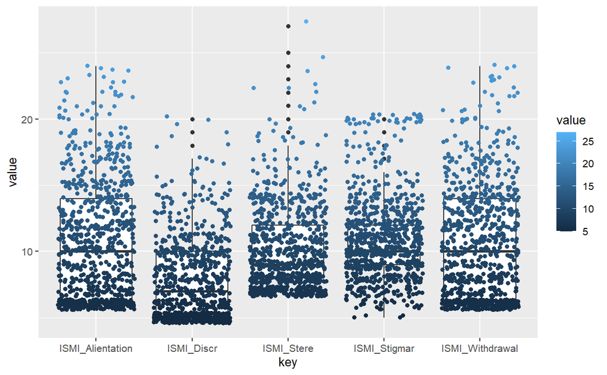

```r
ismi %>% select(ISMI_Alientation,ISMI_Stere,ISMI_Discr,ISMI_Withdrawal,ISMI_Stigmar) %>% gather() %>%  ggplot(aes(y=value,x=key,color=value))+geom_boxplot()+geom_jitter()
```

For some reason, the rescored stigma resistance is a negative correlation

# Distress Disclosure Index

Reverse score items 2, 4, 5, 8, 9, 10. Then sum the 12 items. Higher scores indicate a higher tendency to disclose distress, lower scores indicate greater concealment of distress.

```r
ddi<-ddi %>% mutate(across(c(DDI_2,DDI_4,DDI_5,DDI_8,DDI_9,DDI_10),~6-.)) %>%
  rowwise() %>% mutate(DDI_Total=sum(c_across(DDI_1:DDI_12))) %>%
  ungroup()
```

#BFNE

Consists of 12 items, range 1-5 Items 2, 4, 7, and 10 are reverse scored Forward= c(‘BFNE_1’, ‘BFNE_3’, ‘BFNE_5’, ‘BFNE_6’, ‘BFNE_8’, ‘BFNE_9’, ‘BFNE_11’, ‘BFNE_12’), Reverse= c(‘BFNE_2’, ‘BFNE_4’, ‘BFNE_7’, ‘BFNE_10’)

```r
bfne<-mhhs_data %>% select(contains("bfne"))

bfne<-bfne %>% mutate(across(c(BFNE_2,BFNE_4,BFNE_7,BFNE_10),~6-.))

bfne_scoring<-bfne %>% dplyr::select(BFNE_1:BFNE_12)
key_bfne.list<-list(Total=c(1:12))
key_bfne<-make.keys(12,key_bfne.list,colnames(bfne_scoring))

scales_bfne<-scoreItems(key_bfne.list,bfne_scoring)
summary(scales_bfne)
```

[output not shown]

# Trust respect scale

8 questions 1-strongly disagree; 7 - strongly agree 2,3,5,6 reverse-scored

```r
trs<-mhhs_data %>% select(contains("trs"))

trs<-trs %>% mutate(across(c(TRS_2,TRS_3,TRS_5,TRS_6),~8-.))

trs_scoring<-trs %>% dplyr::select(TRS_1:TRS_8)
key_trs.list<-list(Total=c(1:8))
key_trs<-make.keys(8,key_trs.list,colnames(trs_scoring))

scales_trs<-scoreItems(key_trs.list,trs_scoring)
summary(scales_trs)
```

```
Call: scoreItems(keys = key_trs.list, items = trs_scoring)

Scale intercorrelations corrected for attenuation
 raw correlations below the diagonal, (unstandardized) alpha on the diagonal
 corrected correlations above the diagonal:
      Total
Total  0.91
```

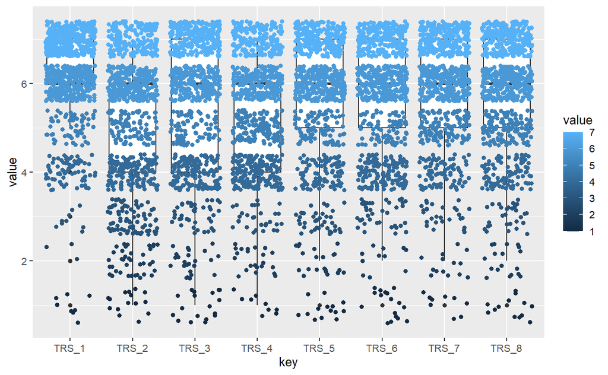

```r
trs %>% select(TRS_1:TRS_8) %>% gather() %>%  ggplot(aes(y=value,x=key,color=value))+geom_boxplot()+geom_jitter()
```

# Trust in Physician Scale

1 (strongly disagree)- 5 (strongly agree) 11 items, unweighted mean of response reverse scored - 1, 5, 7, 11 original scale alpha = .90

```r
tps<-mhhs_data %>% select(contains("tps"))

tps<-tps %>% mutate(across(c(TPS_1,TPS_5,TPS_7,TPS_11),~6-.)) %>%
  rowwise() %>% mutate(TPS_Tot=sum(c_across(TPS_1:TPS_11))) %>%
  ungroup()

#selecting the write-ins
tps %>% filter(TPS_O!="") %>% select(TPS_O)
```

| TPS_O |
| --- |
| Since I am a military dependent, I always get different doctors. I have never had the same doctor longer than 6 months. Every time I find a doctor I can talk to, they leave or move to a different depa… |
| N/A |
| I do not have consistent primary care provider |
| American medical practice is all based on profit so this is difficult |
| My parents care about me a lot and wish to see me happy and fulfilled. However, they are not experts on the matter as they also deal with their own issues. So, I respect their teachings and rely on th… |
| my sister |
| I don't go to the doctor often, and when I do, i go to Patient First, so I don't really have a set doctor |
| I do not think my doctor keeps all of my information private, but I am not worried about it. |
| I do not feel strongly about my doctor, it kind of just feels like they are doing just enough. |
| I believe that my doctor is a reliable resources of help regarding conserving my mental and overall health being. At the moment I don't have any potential concerns. |

[output cut: 50 more lines]

```r
tps_scoring<-tps %>% dplyr::select(TPS_1:TPS_11)
key_tps.list<-list(Total=c(1:11))
key_tps<-make.keys(11,key_tps.list,colnames(tps_scoring))

scales_tps<-scoreItems(key_tps.list,tps_scoring)
summary(scales_tps)
```

```
Call: scoreItems(keys = key_tps.list, items = tps_scoring)

Scale intercorrelations corrected for attenuation
 raw correlations below the diagonal, (unstandardized) alpha on the diagonal
 corrected correlations above the diagonal:
      Total
Total  0.89
```

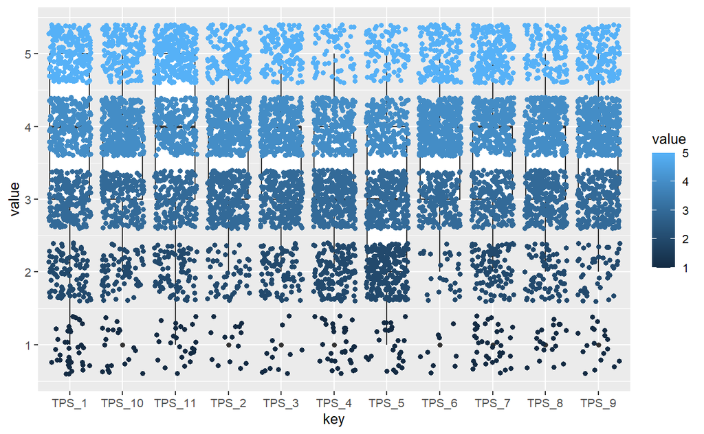

```r
tps %>% select(TPS_1:TPS_11) %>% gather() %>%  ggplot(aes(y=value,x=key,color=value))+geom_boxplot()+geom_jitter()
```

# Ethnic Identity Scale

reverse score 4,5,8

```r
eis<-mhhs_data %>% select(contains("eis"))

# identity questions
eis_id<-eis %>% select(EIS_RE1:EIS_HORIGIN_3_TEXT)
eis_resp<-eis %>% select(!EIS_RE1:EIS_HORIGIN_3_TEXT)

# observe the write-ins
eis_id %>% filter(EIS_RE1_7_TEXT!="") %>% select(EIS_RE1_7_TEXT)
```

| EIS_RE1_7_TEXT |
| --- |
| Biracial (white and chinese) |
| Biracial |
| white/indian |
| Arab |
| Middle eastern |
| Afghan |
| biracial |
| Biracial (Asian Latina) |
| North African |
| arab |

[output cut: 54 more lines]

```r
eis_id %>% filter(EIS_HORIGIN_3_TEXT!="") %>% select(EIS_HORIGIN_3_TEXT)
```

| EIS_HORIGIN_3_TEXT |
| --- |
| Salvadoran |
| bolivian |
| Salvadoran |
| Salvadoran |
| Venezuelan |
| Argentine |
| colombian |
| Cuban Colombian Venezulan |
| Salvadorian |
| Peruvian |

[output cut: 92 more lines]

```r
# selecting responses only
eis_resp<-eis_resp %>% mutate(across(c(EIS_Ethni_4,EIS_Ethni_5,EIS_Ethni_8),~5-.)) %>%
  rowwise() %>% mutate(EIS_Tot=sum(c_across(EIS_Ethni_1:EIS_Ethni_9))) %>%
  ungroup()

eis_scoring<-eis_resp %>% dplyr::select(EIS_Ethni_1:EIS_Ethni_9)
key_eis.list<-list(Total=c(1:9))
key_eis<-make.keys(9,key_eis.list,colnames(eis_scoring))

scales_eis<-scoreItems(key_eis.list,eis_scoring)
summary(scales_eis)
```

```
Call: scoreItems(keys = key_eis.list, items = eis_scoring)

Scale intercorrelations corrected for attenuation
 raw correlations below the diagonal, (unstandardized) alpha on the diagonal
 corrected correlations above the diagonal:
      Total
Total  0.82
```

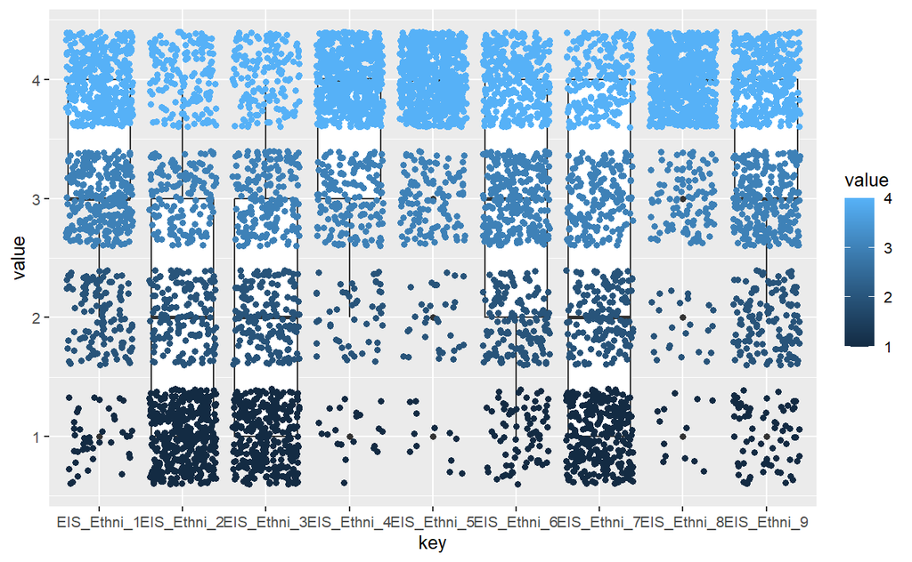

```r
eis_resp %>% select(EIS_Ethni_1:EIS_Ethni_9) %>% gather() %>%  ggplot(aes(y=value,x=key,color=value))+geom_boxplot()+geom_jitter()
```

# Everyday Iniquity - Content

```r
bicf<-mhhs_data %>% select(contains("bicf"))
```

10 items 1=sd 5 =sa

The numbering is a little odd on the original scale. There’s only 10 items numbered to 14. 7 = 5 8 = 6 11 = 7 12 = 8 13 = 9 14 = 10 reverse score 7, 8, 11, 12, 13, 14 only for total subscale mean Harmony: 1, 2*, 3, 6 Higher scores mean higher harmony (affective) Conflict: 7, 8*, 11, 12, 13, 14 Items 2 and 8 are only asked for participants who self-identified as bicultural.

```r
summary(scales_BICII)
```

```
Call: scoreItems(keys = key_BICII.list, items = BICII_scoring)

Scale intercorrelations corrected for attenuation
 raw correlations below the diagonal, (unstandardized) alpha on the diagonal
 corrected correlations above the diagonal:
      Total
Total  0.89
```

# Tosca-3

# Relationship assessment scale

# Combining scales for projects

```r
kayleighdata<-cbind(mhhs_data$ResponseId,demographics,bicii,eis,ghsql,ismi,trs,tps)
```

[output not shown]